# Version 10 results: four panel figures

### Figure S4

**Show the code that produced this**

```
  Figure_S4 [es] 175x178 mm; fonts 6.0–11.0 pt; off-canvas: 0; overlaps: 0
  Figure_S4 [en] 175x178 mm; fonts 6.0–11.0 pt; off-canvas: 0; overlaps: 0
```

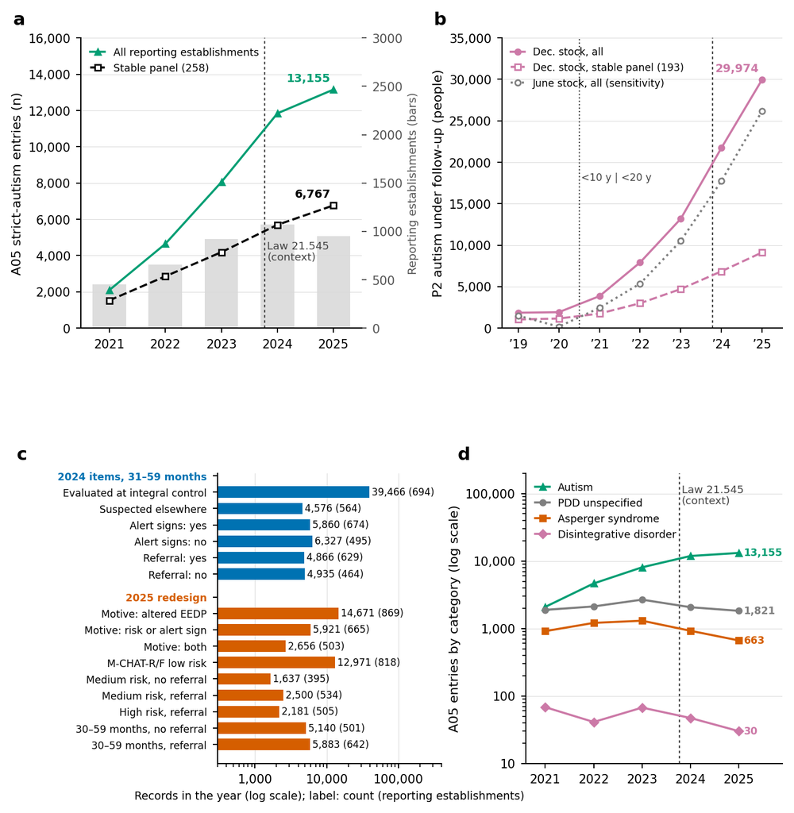

Figure S4. Drawn by the code above from the public tables in docs/study/data/.

```python
def figS4(lang):
    style(); fig = plt.figure(figsize=(175/25.4, 178/25.4))
    gs = fig.add_gridspec(2, 2, left=0.10, right=0.975, top=0.965, bottom=0.075, hspace=0.50, wspace=0.50)
    # (a) A05 entries: observed network vs stable panel, with establishments
    a = fig.add_subplot(gs[0, 0]); clean(a)
    ent = rem_series('05990022'); a2 = a.twinx(); a2.grid(False); a2.spines['top'].set_visible(False)
    [p_.set_gid('bg') for p_ in a2.bar(ent.index, ent.n_reporting_establishments, color='#dddddd', width=0.6, zorder=0)]; a2.set_ylim(0, 3000); a2.set_ylabel(text('Reporting establishments (bars)', 'Establecimientos informantes (barras)', lang), fontsize=7, color='#555555'); a2.tick_params(axis='y', colors='#555555')
    a.set_zorder(a2.get_zorder() + 1); a.patch.set_visible(False)
    a.plot(ent.index, ent.total, color=GREEN, marker='^', label=text('All reporting establishments', 'Todos los establecimientos informantes', lang))
    a.plot(ent.index, ent.stable_panel_total, color=BLACK, marker='s', mfc='white', ls='--', label=text('Stable panel (258)', 'Panel estable (258)', lang))
    for s_, col in ((ent.total, GREEN), (ent.stable_panel_total, BLACK)):
        end_label(a, 2025, s_[2025], num(s_[2025], lang), col, dx=-2, dy=7, ha='right')
    law_line(a, lang, y=0.30); a.set_ylim(0, 16000); a.yaxis.set_major_formatter(thousands(lang)); year_ticks(a, YRS_REM); a.set_xlim(2020.5, 2025.5)
    a.set_ylabel(text('A05 strict-autism entries (n)', 'Ingresos A05 autismo estricto (n)', lang)); a.legend(loc='upper left', fontsize=6.4, handlelength=1.4)
    # (b) P2 December and June stocks, observed vs stable panel
    b = fig.add_subplot(gs[0, 1]); clean(b)
    pd_ = rem_series('P2500500', measure='december_stock'); pj = rem_series('P2500500', measure='june_stock')
    b.plot(pd_.index, pd_.total, color=PINK, marker='o', label=text('Dec. stock, all', 'Stock dic., todos', lang))
    b.plot(pd_.index, pd_.stable_panel_total, color=PINK, marker='s', mfc='white', ls='--', label=text('Dec. stock, stable panel (193)', 'Stock dic., panel estable (193)', lang))
    b.plot(pj.index, pj.total, color=GREY, marker='o', mfc='white', ls=':', label=text('June stock, all (sensitivity)', 'Stock junio, todos (sensibilidad)', lang))
    b.axvline(2020.5, color='#444444', ls=':', lw=0.8); b.text(2020.55, 0.50, text('<10 y | <20 y', '<10 a | <20 a', lang), transform=b.get_xaxis_transform(), fontsize=6.2, va='bottom', color='#444444')
    end_label(b, 2025, pd_.total[2025], num(pd_.total[2025], lang), PINK, dx=-2, dy=7, ha='right')
    law_line(b, lang, y=0.40, label=False); b.set_ylim(0, 35000); b.yaxis.set_major_formatter(thousands(lang)); year_ticks(b, range(2019, 2026), short=True); b.set_xlim(2018.6, 2025.5)
    b.set_ylabel(text('P2 autism under follow-up (people)', 'P2 autismo en seguimiento (personas)', lang)); b.legend(loc='upper left', fontsize=6.2, handlelength=1.4)
    # (c) A03 2024 additional items and the 2025 redesign
    c = fig.add_subplot(gs[1, 0]); clean(c, grid='x'); pos = c.get_position(); c.set_position([pos.x0 + 0.17, pos.y0, pos.width - 0.07, pos.height])
    r = pd.read_csv(TIDY/'rem_pathway_annual.csv', low_memory=False); r['code'] = r.code.astype(str)
    rows = [(cd, en, es, 2024, BLUE) for cd, en, es in A03_2024] + [(cd, en, es, 2025, ORANGE) for cd, en, es in A03_2025]
    y = 0; ticks = []; labels = []; heads = []
    for i, (cd, en, es, yr, col) in enumerate(rows):
        if i == 0 or i == len(A03_2024):
            if i: y += 0.4
            ticks.append(y); labels.append(text('2024 items, 31–59 months', 'Ítems 2024, 31–59 meses', lang) if i == 0 else text('2025 redesign', 'Rediseño 2025', lang)); heads.append((len(ticks) - 1, col)); y += 1
        z = r[(r.code == cd) & (r.variant == 'single_code') & (r.year == yr)]; v = float(z.total.iloc[0]); n = int(z.n_reporting_establishments.iloc[0])
        c.barh(y, v, color=col, height=0.7); c.text(v * 1.08, y, f'{num(v, lang)} ({n})', va='center', fontsize=6.0); ticks.append(y); labels.append(text(en, es, lang)); y += 1
    c.set_yticks(ticks); c.set_yticklabels(labels, fontsize=6.2); c.invert_yaxis(); log_axis(c, 'x', lang); c.set_xlim(300, 400000); c.set_xticks([1000, 10000, 100000]); c.xaxis.set_major_formatter(thousands(lang))
    for idx, col in heads:
        t = c.get_yticklabels()[idx]; t.set_color(col); t.set_fontweight('bold')
    c.set_xlabel(text('Records in the year (log scale); label: count (reporting establishments)', 'Registros del año (escala log); etiqueta: recuento (establecimientos)', lang), fontsize=6.8)
    # (d) A05 entries by REM category, 2021–2025
    d = fig.add_subplot(gs[1, 1]); clean(d); pos = d.get_position(); d.set_position([pos.x0 + 0.03, pos.y0, pos.width - 0.03, pos.height])
    cats = [('05990022', 'Autism', 'Autismo', GREEN, '^'), ('05990026', 'PDD unspecified', 'TGD no especificado', GREY, 'o'), ('05990023', 'Asperger syndrome', 'Síndrome de Asperger', ORANGE, 's'), ('05990025', 'Disintegrative disorder', 'Trastorno desintegrativo', PINK, 'D')]
    for cd, en, es, col, mk in cats:
        z = rem_series(cd).reindex(YRS_REM); d.plot(z.index, z.total, color=col, marker=mk, label=text(en, es, lang)); end_label(d, 2025, z.total[2025], num(z.total[2025], lang), col, dx=3, size=6.2)
    log_axis(d, 'y', lang); d.set_ylim(10, 200000); year_ticks(d, YRS_REM); d.set_xlim(2020.6, 2025.9); law_line(d, lang, y=0.96)
    d.set_ylabel(text('A05 entries by category (log scale)', 'Ingresos A05 por categoría (escala log)', lang)); d.legend(loc='upper left', fontsize=6.4, handlelength=1.4)
    for ax, ch in zip([a, b, c, d], 'abcd'): letter(fig, ax, ch, dx=(-0.25 if ch == 'c' else -0.085))
    save(fig, 'Figure_S4', lang, close=False)
    return fig

plt.close(figS4('es'))          # Spanish plate: exported to docs/study/figures/es/
figS4('en')                     # English plate: exported and shown here
```

### Figure S5

**Show the code that produced this**

```
  Figure_S5 [es] 175x150 mm; fonts 5.8–11.0 pt; off-canvas: 0; overlaps: 0
```

```
  Figure_S5 [en] 175x150 mm; fonts 5.8–11.0 pt; off-canvas: 0; overlaps: 0
```

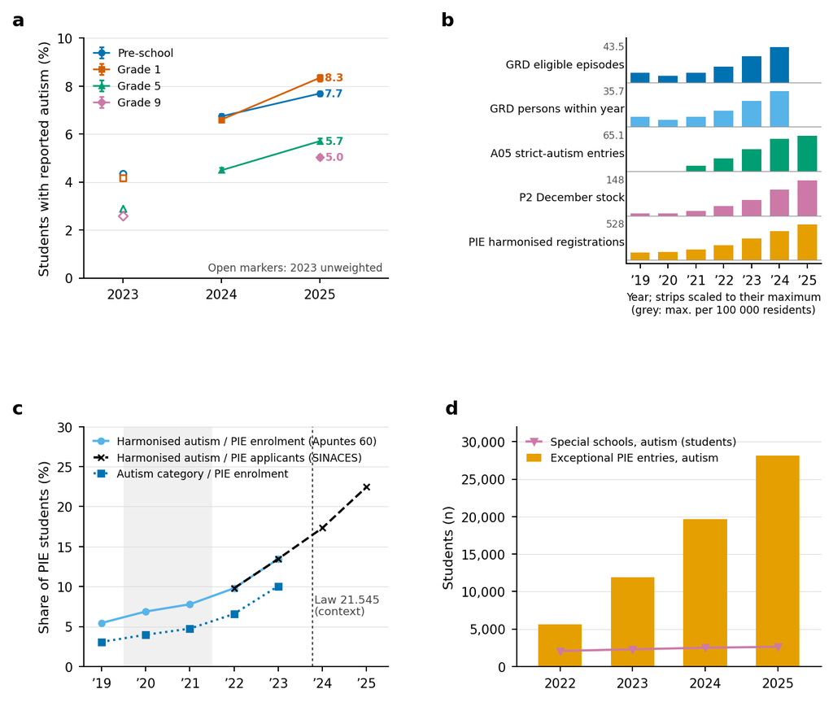

Figure S5. Drawn by the code above from the public tables in docs/study/data/.

```python
def figS5(lang):
    style(); fig = plt.figure(figsize=(175/25.4, 150/25.4))
    gs = fig.add_gridspec(2, 2, left=0.10, right=0.975, top=0.96, bottom=0.09, hspace=0.62, wspace=0.42)
    ed = pd.read_csv(TIDY/'education_summary_year.csv').set_index('year'); pop = pd.read_csv(TIDY/'coverage_layers_year.csv').set_index('year').ine_population_base2017_30jun
    # (a) JUNAEB reported autism by grade
    a = fig.add_subplot(gs[0, 0]); clean(a)
    levels = [('parvularia', 'Pre-school', 'Prekínder–kínder', BLUE, 'o'), ('basico1', 'Grade 1', '1º básico', ORANGE, 's'), ('basico5', 'Grade 5', '5º básico', GREEN, '^'), ('medio1', 'Grade 9', '1º medio', PINK, 'D')]
    for key, en, es, col, mk in levels:
        w = ed[f'junaeb_{key}_pct_weighted']; lo = ed[f'junaeb_{key}_pct_weighted_lo']; hi = ed[f'junaeb_{key}_pct_weighted_hi']; u = ed[f'junaeb_{key}_pct_unweighted']
        yy = w.dropna().index
        a.errorbar(yy, w[yy], yerr=[w[yy] - lo[yy], hi[yy] - w[yy]], fmt=mk + '-', color=col, ms=3.2, capsize=1.5, lw=1, label=text(en, es, lang))
        u23 = u.get(2023, np.nan)
        if not np.isnan(u23): a.scatter([2023], [u23], marker=mk, s=14, facecolors='white', edgecolors=col, linewidths=1.0, zorder=3)
        if len(yy): end_label(a, yy[-1], w[yy[-1]], num(w[yy[-1]], lang, 1), col, dx=3, size=6.2)
    a.set_ylim(0, 10); a.set_xlim(2022.6, 2025.7); a.set_xticks([2023, 2024, 2025]); a.set_ylabel(text('Students with reported autism (%)', 'Estudiantes con autismo reportado (%)', lang))
    a.legend(loc='upper left', fontsize=6.4, handlelength=1.4); a.text(0.98, 0.03, text('Open markers: 2023 unweighted', 'Marcadores vacíos: 2023 sin ponderar', lang), transform=a.transAxes, ha='right', fontsize=6.2, color='#444444')
    # (b) records per 100 000 residents, crude, one strip per system
    b = fig.add_subplot(gs[0, 1]); clean(b, grid=None)
    g = load_grd_summary().query("panel=='observed' and position=='any'").set_index('year')
    strips = [('GRD eligible episodes', 'Episodios GRD elegibles', (g.n_episodes_f84 / pop.reindex(g.index) * 1e5), BLUE),
              ('GRD persons within year', 'Personas GRD dentro del año', (g.persons_within_year / pop.reindex(g.index) * 1e5), SKY),
              ('A05 strict-autism entries', 'Ingresos A05 autismo estricto', (rem_series('05990022').total / pop * 1e5).dropna(), GREEN),
              ('P2 December stock', 'Stock P2 de diciembre', (rem_series('P2500500', measure='december_stock').total / pop * 1e5).dropna(), PINK),
              ('PIE harmonised registrations', 'Registros PIE armonizados', (ed.pie_harmonised_n / pop.reindex(ed.index) * 1e5).dropna(), GOLD)]
    n = len(strips); yrs = list(range(2019, 2026))
    for i, (en, es, ser, col) in enumerate(strips):
        base = (n - 1 - i) * 1.25; mx = float(ser.max())
        for yv in yrs:
            if yv in ser.index and not np.isnan(ser[yv]): b.bar(yv, ser[yv] / mx, bottom=base, width=0.7, color=col, zorder=2)
        b.text(2018.45, base + 0.5, text(en, es, lang), ha='right', va='center', fontsize=6.4)
        b.text(2018.45, base + 1.0, num(mx, lang, 1 if mx < 100 else 0), ha='right', va='center', fontsize=5.8, color='#555555')
        b.axhline(base, color='#999999', lw=0.5)
    b.set_ylim(-0.1, n * 1.25); b.set_yticks([]); b.set_xticks(yrs); b.set_xticklabels(["’" + str(y)[2:] for y in yrs]); b.set_xlim(2018.5, 2025.5)
    b.set_xlabel(text('Year; strips scaled to their maximum\n(grey: max. per 100 000 residents)', 'Año; franjas escaladas a su máximo\n(gris: máx. por 100 000 residentes)', lang), fontsize=6.2)
    pos = b.get_position(); b.set_position([pos.x0 + 0.13, pos.y0 + 0.02, pos.width - 0.13, pos.height - 0.02])
    # (c) PIE share of total PIE enrolment
    c = fig.add_subplot(gs[1, 0]); clean(c); shade_pandemic(c)
    c.plot(ed.index, ed.pie_harmonised_share_of_pie_pct, color=SKY, marker='o', label=text('Harmonised autism / PIE enrolment (Apuntes 60)', 'Armonizado / matrícula PIE (Apuntes 60)', lang))
    c.plot(ed.index, ed.pie_harmonised_share_of_applicants_sinaces_pct, color=BLACK, marker='x', ls='--', label=text('Harmonised autism / PIE applicants (SINACES)', 'Armonizado / postulantes PIE (SINACES)', lang))
    c.plot(ed.index, ed.pie_tea_strict_share_of_pie_pct, color=BLUE, marker='s', ls=':', label=text('Autism category / PIE enrolment', 'Categoría autismo / matrícula PIE', lang))
    law_line(c, lang, y=0.30); c.set_ylim(0, 30); year_ticks(c, range(2019, 2026), short=True); c.set_xlim(2018.6, 2025.5)
    c.set_ylabel(text('Share of PIE students (%)', 'Proporción de estudiantes PIE (%)', lang)); c.legend(loc='upper left', fontsize=6.2, handlelength=1.4)
    # (d) special schools and exceptional entries
    d = fig.add_subplot(gs[1, 1]); clean(d)
    d.bar(ed.index, ed.pie_tea_exceptional_entry_n, color=GOLD, width=0.6, label=text('Exceptional PIE entries, autism', 'Ingresos excepcionales PIE, autismo', lang), zorder=2)
    d.plot(ed.index, ed.special_schools_autism_n, color=PINK, marker='v', label=text('Special schools, autism (students)', 'Escuelas especiales, autismo (estudiantes)', lang))
    d.set_ylim(0, 32000); d.yaxis.set_major_formatter(thousands(lang)); d.set_xticks([2022, 2023, 2024, 2025]); d.set_xlim(2021.4, 2025.6)
    d.set_ylabel(text('Students (n)', 'Estudiantes (n)', lang)); d.legend(loc='upper left', fontsize=6.4, handlelength=1.4)
    for ax, ch in zip([a, b, c, d], 'abcd'): letter(fig, ax, ch, dx=(-0.22 if ch == 'b' else -0.085))
    save(fig, 'Figure_S5', lang, close=False)
    return fig

plt.close(figS5('es'))          # Spanish plate: exported to docs/study/figures/es/
figS5('en')                     # English plate: exported and shown here
```

### Figure S6

**Show the code that produced this**

```
  Figure_S6 [es] 175x213 mm; fonts 7.0–11.0 pt; off-canvas: 0; overlaps: 0
  Figure_S6 [en] 175x213 mm; fonts 7.0–11.0 pt; off-canvas: 0; overlaps: 0
```

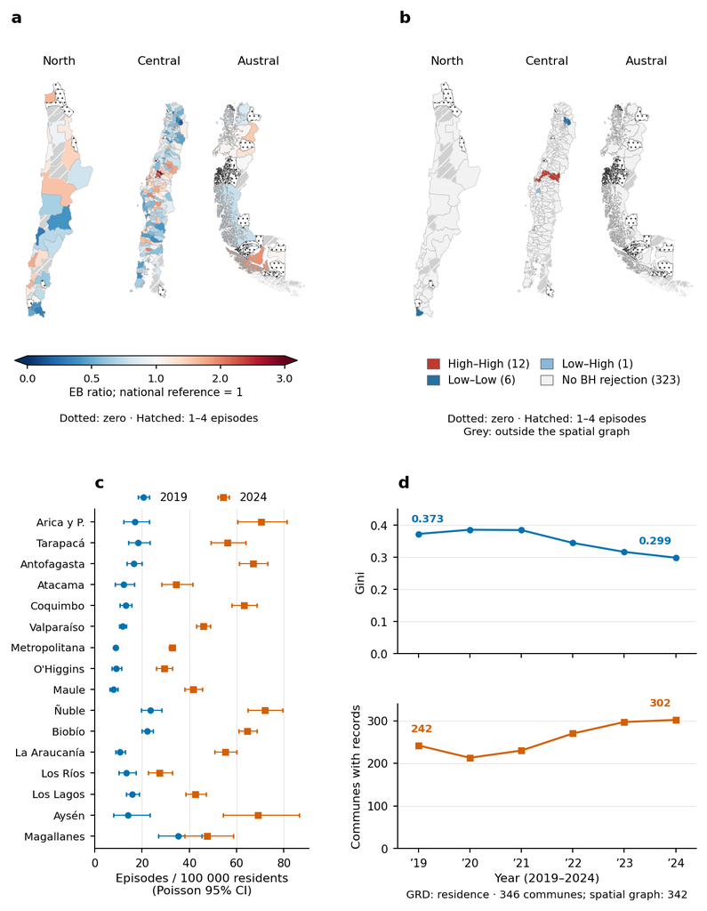

Figure S6. Drawn by the code above from the public tables in docs/study/data/.

```python
def figS6(lang):
    style(); plt.rcParams['hatch.linewidth'] = 0.55      # fine dots and slashes, as on the inherited plate
    fig = plt.figure(figsize=(S6_W/300, S6_H/300))
    import matplotlib.colors as mcolors
    from matplotlib.patches import Patch

    # ---- commune-level inputs of the two maps ------------------------------------------------
    e40 = pd.read_csv(CORPUS/'E40_grd_smoothed_ratio_comuna.csv')
    e40.columns = [c.lstrip('') for c in e40.columns]                 # the header carries a BOM
    obs = e40['Observed episodes'].astype(str).str.strip()
    e40['disclosure'] = np.where(obs == '0', 'zero', np.where(obs == '<5', 'masked', 'shown'))
    e40['eb'] = e40['Empirical-Bayes smoothed standardised ratio'].astype(float)
    n_comunas = len(e40)
    e51 = pd.read_csv(CORPUS/'E51_lisa_significant_comunas.csv').query("Indicator=='GRD F84 episodes'")
    e42 = pd.read_csv(CORPUS/'E42_local_class_counts.csv').query("Indicator=='GRD F84 episodes'").iloc[0]
    counts = {'High–High': int(e42['LISA HH']), 'Low–Low': int(e42['LISA LL']),
              'Low–High': int(e42['LISA LH']), 'none': int(e42['LISA not significant'])}
    n_graph = sum(counts.values()) + int(e42['LISA HL'])
    assert e51.LISA.value_counts().to_dict() == {k: v for k, v in counts.items() if k != 'none' and v}, \
        'E51 rows and E42 counts disagree'                                  # legend counts cannot drift
    gdf = _s6_communes().merge(e40[['CUT', 'eb', 'disclosure']], on='CUT', how='left')
    gdf = gdf.merge(e51[['CUT', 'LISA']], on='CUT', how='left')
    gdf['LISA'] = gdf.LISA.fillna('none')

    # ---- (a) empirical-Bayes smoothed standardised ratio -------------------------------------
    norm = mcolors.TwoSlopeNorm(vmin=0, vcenter=1, vmax=3)

    def draw_a(ax, sub):
        shown = sub[(sub.disclosure == 'shown') & ~sub.CUT.isin(S6_OFFGRAPH)]
        if len(shown): shown.plot(ax=ax, column='eb', cmap='RdBu_r', norm=norm, edgecolor=S6_EDGE, linewidth=0.17)
        _s6_disclosure(ax, sub)

    axa = _s6_strips(fig, gdf, lang, 0.0, draw_a)
    cax = fig.add_axes([126/S6_W, (S6_H - 992)/S6_H, (919 - 126)/S6_W, 26/S6_H])
    ticks = [0, 0.5, 1, 2, 3]
    cb = fig.colorbar(plt.cm.ScalarMappable(cmap='RdBu_r', norm=norm), cax=cax, orientation='horizontal',
                      extend='both', ticks=ticks)
    labs = [num(v, lang, 1) for v in ticks]
    if lang == 'es': labs = [s[:-2] if s.endswith(',0') else s for s in labs]
    cb.ax.set_xticklabels(labs); cb.ax.tick_params(labelsize=7.2, length=2.5, width=0.7)
    cb.outline.set_linewidth(0.6)
    cb.set_label(text('EB ratio; national reference = 1', 'Razón EB; referencia nacional = 1', lang),
                 fontsize=7.4, labelpad=2)
    dots = text('Dotted: zero · Hatched: 1–4 episodes', 'Punteado: cero · Rayado: 1–4 episodios', lang)
    fig.text(S6_CENTRES[1]/S6_W, (S6_H - 1157)/S6_H, dots, ha='center', va='bottom', fontsize=7.2)

    # ---- (b) local Moran clusters -------------------------------------------------------------
    def draw_b(ax, sub):
        for key, col in S6_CLUSTER.items():
            z = sub[(sub.LISA == key) & ~sub.CUT.isin(S6_OFFGRAPH)]
            if len(z): z.plot(ax=ax, color=col, edgecolor=S6_EDGE, linewidth=0.17)
        _s6_disclosure(ax, sub)

    axb = _s6_strips(fig, gdf, lang, S6_PANEL_DX, draw_b)
    names = {'High–High': ('High–High', 'Alto–Alto'), 'Low–Low': ('Low–Low', 'Bajo–Bajo'),
             'Low–High': ('Low–High', 'Bajo–Alto'), 'none': ('No BH rejection', 'Sin rechazo BH')}
    order = ['High–High', 'Low–Low', 'Low–High', 'none']
    lax = fig.add_axes([1244/S6_W, (S6_H - 1078)/S6_H, (2030 - 1244)/S6_W, 116/S6_H])
    lax.set_axis_off(); lax.grid(False)
    lax.legend(handles=[Patch(fc=S6_CLUSTER[k], ec='#6b6b6b', lw=0.5,
                              label=f'{text(*names[k], lang)} ({num(counts[k], lang)})') for k in order],
               loc='upper center', ncol=2, fontsize=7.4, handlelength=1.1, handleheight=1.0,
               columnspacing=1.0, labelspacing=0.5, borderaxespad=0, frameon=False)
    fig.text((S6_CENTRES[1] + S6_PANEL_DX)/S6_W, (S6_H - 1194)/S6_H,
             dots + '\n' + text('Grey: outside the spatial graph', 'Gris: fuera del grafo espacial', lang),
             ha='center', va='bottom', fontsize=7.2, linespacing=1.3)

    # ---- (c) regional endpoints, 2019 and 2024 ------------------------------------------------
    ef9 = pd.read_csv(CORPUS/'EF9_territory.csv')
    ef9 = ef9[~ef9['Region of residence'].isin(['Without a linkable comuna', 'National total'])]
    y0, y1 = ef9.columns[1], ef9.columns[-1]

    def cell(s):
        rate, ci = s.split(';')[1].split('(')
        lo, hi = ci.rstrip(') ').split('–')
        return float(rate), float(lo), float(hi)

    c = fig.add_axes([351/S6_W, (S6_H - 2347)/S6_H, (951 - 351)/S6_W, (2347 - 1396)/S6_H]); clean(c, grid='x')
    for yr, col, mk in ((y0, BLUE, 'o'), (y1, ORANGE, 's')):
        v = np.array([cell(s) for s in ef9[yr]])
        c.errorbar(v[:, 0], np.arange(len(v)), xerr=[v[:, 0] - v[:, 1], v[:, 2] - v[:, 0]], fmt=mk,
                   color=col, ms=3.4, capsize=1.4, elinewidth=0.7, lw=0, label=yr)
    c.set_yticks(range(len(ef9)))
    c.set_yticklabels([r.replace('Arica y Parinacota', 'Arica y P.') for r in ef9['Region of residence']], fontsize=7.2)
    c.invert_yaxis(); c.set_xlim(left=0); c.set_ylim(len(ef9) - 0.4, -0.6)   # autoscale: a fixed
    # upper limit of 80 clipped the 2024 upper Poisson bounds of 81.2 and 86.6 out of the plot.
    c.set_xlabel(text('Episodes / 100 000 residents\n(Poisson 95% CI)', 'Episodios / 100 000 residentes\n(IC 95% de Poisson)', lang))
    c.legend(loc='lower center', bbox_to_anchor=(0.5, 1.005), ncol=2, fontsize=7.4, handlelength=1.3, columnspacing=2.6, borderaxespad=0)

    # ---- (d) concentration and coverage -------------------------------------------------------
    e47 = pd.read_csv(CORPUS/'E47_inequality_gini_theil.csv').query("Indicator=='GRD F84 episodes'")
    yrs = [int(p) for p in e47.Period if p.isdigit()]
    ann = e47[e47.Period.isin([str(y) for y in yrs])].set_index('Period')
    gini = [float(ann.loc[str(y), 'Gini index']) for y in yrs]
    with_records = [n_comunas - int(ann.loc[str(y), 'Comunas with zero']) for y in yrs]
    d1 = fig.add_axes([1200/S6_W, (S6_H - 1801)/S6_H, (2037 - 1200)/S6_W, (1801 - 1396)/S6_H]); clean(d1)
    d1.plot(yrs, gini, color=BLUE, marker='o')
    end_label(d1, yrs[0], gini[0], num(gini[0], lang, 3), BLUE, dx=-5, dy=10)
    end_label(d1, yrs[-1], gini[-1], num(gini[-1], lang, 3), BLUE, dx=-3, dy=11, ha='right')
    d1.set_ylim(0, 0.45); d1.set_yticks([0, 0.1, 0.2, 0.3, 0.4])
    gl = [num(v, lang, 1) for v in [0, 0.1, 0.2, 0.3, 0.4]]
    d1.set_yticklabels([g[:-2] if lang == 'es' and g.endswith(',0') else g for g in gl])
    d1.set_ylabel(text('Gini', 'Gini', lang))
    year_ticks(d1, yrs, short=True); d1.set_xlim(yrs[0] - 0.4, yrs[-1] + 0.4); d1.set_xticklabels([])
    d2 = fig.add_axes([1200/S6_W, (S6_H - 2347)/S6_H, (2037 - 1200)/S6_W, (2347 - 1941)/S6_H]); clean(d2)
    d2.plot(yrs, with_records, color=ORANGE, marker='s')
    end_label(d2, yrs[0], with_records[0], num(with_records[0], lang), ORANGE, dx=-5, dy=11)
    end_label(d2, yrs[-1], with_records[-1], num(with_records[-1], lang), ORANGE, dx=-3, dy=11, ha='right')
    d2.set_ylim(0, 340); d2.set_yticks([0, 100, 200, 300]); d2.yaxis.set_major_formatter(thousands(lang))
    d2.set_ylabel(text('Communes with records', 'Comunas con registros', lang))
    year_ticks(d2, yrs, short=True); d2.set_xlim(yrs[0] - 0.4, yrs[-1] + 0.4)
    d2.set_xlabel(text(f'Year ({yrs[0]}–{yrs[-1]})', f'Año ({yrs[0]}–{yrs[-1]})', lang))
    fig.text((1200 + 2037)/2/S6_W, (S6_H - 2492)/S6_H,
             text(f'GRD: residence · {num(n_comunas, lang)} communes; spatial graph: {num(n_graph, lang)}',
                  f'GRD: residencia · {num(n_comunas, lang)} comunas; grafo espacial: {num(n_graph, lang)}', lang),
             ha='center', va='bottom', fontsize=7.2)
    for ax, ch in ((axa[0], 'a'), (axb[0], 'b')): letter(fig, ax, ch, dx=-0.020, dy=0.062)
    letter(fig, c, 'c', dx=0.0, dy=0.020); letter(fig, d1, 'd', dx=0.0, dy=0.020)
    save(fig, 'Figure_S6', lang, close=False)
    return fig

plt.close(figS6('es'))          # Spanish plate: exported to docs/study/figures/es/
figS6('en')                     # English plate: exported and shown here
```

### Figure S7

**Show the code that produced this**

```
  Figure_S7 [es] 175x165 mm; fonts 6.4–11.0 pt; off-canvas: 0; overlaps: 0
  Figure_S7 [en] 175x165 mm; fonts 6.4–11.0 pt; off-canvas: 0; overlaps: 0
```

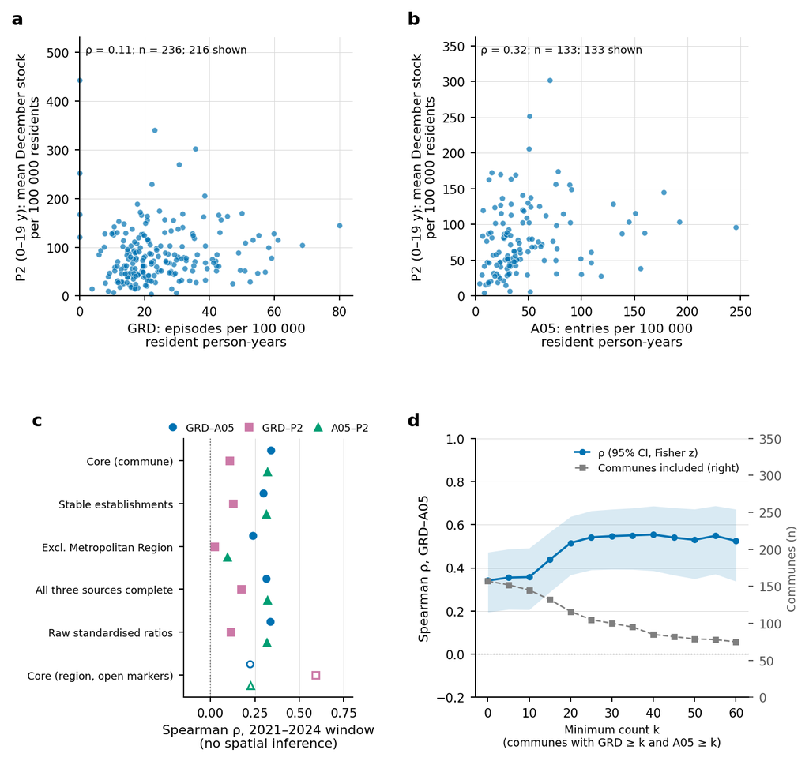

Figure S7. Drawn by the code above from the public tables in docs/study/data/.

```python
def figS7(lang):
    style(); fig = plt.figure(figsize=(175/25.4, 165/25.4))
    gs = fig.add_gridspec(2, 2, left=0.10, right=0.935, top=0.965, bottom=0.09, hspace=0.55, wspace=0.45)
    # Public extract: cells with 1-4 records are masked per variable, so dropna() leaves exactly the displayed communes.
    base = pd.read_csv(DATA/'communes_public.csv'); corr = pd.read_csv(DATA/'S4_correlations_selected_sensitivities.csv')
    def scatter(ax, x, y, xl, yl):
        z = base.dropna(subset=[x, y])
        ax.scatter(z[x], z[y], s=12, color=BLUE, alpha=0.7, edgecolors='white', linewidths=0.3, clip_on=False)
        r = corr[(corr.pair == x + '–' + y) & (corr.scope == 'commune') & (corr.analysis == 'core')].iloc[0]
        ax.text(0.02, 0.97, f'ρ = {num(r.rho, lang, 2)}; n = {int(r.n)}; {len(z)} ' + text('shown', 'visibles', lang), transform=ax.transAxes, va='top', fontsize=6.6)
        ax.set_xlabel(xl); ax.set_ylabel(yl); ax.set_xlim(left=0); ax.set_ylim(0, float(z[y].max()) * 1.2)
    a = fig.add_subplot(gs[0, 0]); clean(a, grid='both')
    scatter(a, 'GRD', 'P2', text('GRD: episodes per 100 000\nresident person-years', 'GRD: episodios por 100 000\npersonas-año residentes', lang), text('P2 (0–19 y): mean December stock\nper 100 000 residents', 'P2 (0–19 años): stock medio de diciembre\npor 100 000 residentes', lang))
    b = fig.add_subplot(gs[0, 1]); clean(b, grid='both')
    scatter(b, 'A05', 'P2', text('A05: entries per 100 000\nresident person-years', 'A05: ingresos por 100 000\npersonas-año residentes', lang), text('P2 (0–19 y): mean December stock\nper 100 000 residents', 'P2 (0–19 años): stock medio de diciembre\npor 100 000 residentes', lang))
    # (c) coefficients by analysis and scale
    c = fig.add_subplot(gs[1, 0]); clean(c, grid='x'); pos = c.get_position(); c.set_position([pos.x0 + 0.13, pos.y0, pos.width - 0.13, pos.height])
    analyses = [('core', 'Core (commune)', 'Base (comuna)'), ('stable_establishments', 'Stable establishments', 'Establecimientos estables'), ('exclude_metropolitan', 'Excl. Metropolitan Region', 'Sin Región Metropolitana'),
                ('all_three_complete', 'All three sources complete', 'Tres fuentes completas'), ('raw_sir', 'Raw standardised ratios', 'Razones estandarizadas crudas')]
    pairs = [('GRD–A05', BLUE, 'o'), ('GRD–P2', PINK, 's'), ('A05–P2', GREEN, '^')]
    ticks = []; labels = []
    for i, (an, en, es) in enumerate(analyses):
        for j, (pair, col, mk) in enumerate(pairs):
            z = corr[(corr.pair == pair) & (corr.scope == 'commune') & (corr.analysis == an)]
            if len(z): c.plot(z.rho.iloc[0], i + (j - 1) * 0.25, mk, color=col, ms=4, label=pair if i == 0 else None)
        ticks.append(i); labels.append(text(en, es, lang))
    reg = corr[(corr.scope == 'region') & (corr.analysis == 'core')]
    for j, (pair, col, mk) in enumerate(pairs):
        z = reg[reg.pair == pair]
        if len(z): c.plot(z.rho.iloc[0], len(analyses) + (j - 1) * 0.25, mk, color=col, ms=4, mfc='white')
    ticks.append(len(analyses)); labels.append(text('Core (region, open markers)', 'Base (región, marcadores vacíos)', lang))
    c.set_yticks(ticks); c.set_yticklabels(labels, fontsize=6.4); c.invert_yaxis(); c.axvline(0, color='#777', ls=':', lw=0.7); c.set_xlim(-0.15, 0.8)
    c.set_xlabel(text('Spearman ρ, 2021–2024 window\n(no spatial inference)', 'ρ de Spearman, ventana 2021–2024\n(sin inferencia espacial)', lang)); c.legend(loc='lower center', bbox_to_anchor=(0.5, 1.0), ncol=3, fontsize=6.4, handlelength=1, columnspacing=0.9, frameon=False, borderaxespad=0.1)
    # (d) sensitivity of GRD–A05 to the minimum count threshold
    d = fig.add_subplot(gs[1, 1]); clean(d)
    # Precomputed on the complete analytic file (manuscript values); see the module docstring.
    ts = pd.read_csv(DATA/'S7d_threshold_sensitivity.csv'); ks = ts.k.tolist(); rhos = ts.rho.tolist(); los = ts.rho_lo.tolist(); his = ts.rho_hi.tolist(); ns = ts.n_communes.tolist()
    d.fill_between(ks, los, his, color=BLUE, alpha=0.15, lw=0); d.plot(ks, rhos, color=BLUE, marker='o', ms=3, label=text('ρ (95% CI, Fisher z)', 'ρ (IC 95%, z de Fisher)', lang))
    d.axhline(0, color='#777', ls=':', lw=0.7); d.set_ylim(-0.2, 1); d.set_ylabel(text('Spearman ρ, GRD–A05', 'ρ de Spearman, GRD–A05', lang)); d.set_xlabel(text('Minimum count k\n(communes with GRD ≥ k and A05 ≥ k)', 'Recuento mínimo k\n(comunas con GRD ≥ k y A05 ≥ k)', lang), fontsize=6.8)
    d2 = d.twinx(); d2.grid(False); d2.spines['top'].set_visible(False); d2.plot(ks, ns, color=GREY, marker='s', ms=2.6, ls='--', lw=0.9, label=text('Communes included (right)', 'Comunas incluidas (derecha)', lang)); d2.set_ylim(0, 350); d2.set_ylabel(text('Communes (n)', 'Comunas (n)', lang), fontsize=7.2, color='#555555'); d2.tick_params(axis='y', colors='#555555')
    h1, l1 = d.get_legend_handles_labels(); h2, l2 = d2.get_legend_handles_labels(); d.legend(h1 + h2, l1 + l2, loc='upper right', fontsize=6.4, handlelength=1.4)
    for ax, ch in zip([a, b, c, d], 'abcd'): letter(fig, ax, ch, dx=(-0.19 if ch == 'c' else -0.085))
    save(fig, 'Figure_S7', lang, close=False)
    return fig

plt.close(figS7('es'))          # Spanish plate: exported to docs/study/figures/es/
figS7('en')                     # English plate: exported and shown here
```

### Figure S8

**Show the code that produced this**

```
  Figure_S8 [es] 175x95 mm; fonts 6.0–11.0 pt; off-canvas: 0; overlaps: 0
  Figure_S8 [en] 175x95 mm; fonts 6.0–11.0 pt; off-canvas: 0; overlaps: 0
```

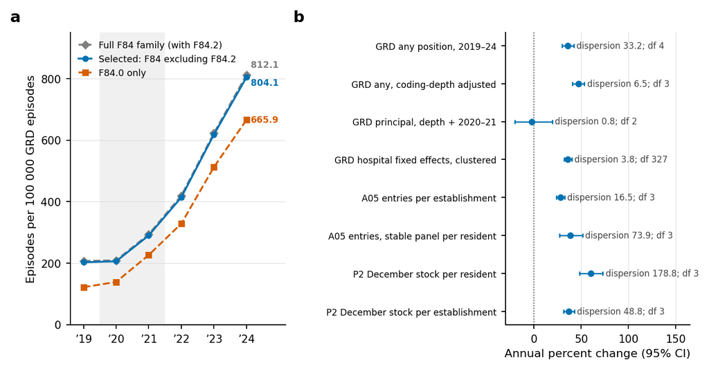

Figure S8. Drawn by the code above from the public tables in docs/study/data/.

```python
def figS8(lang):
    style(); fig = plt.figure(figsize=(175/25.4, 95/25.4))
    gs = fig.add_gridspec(1, 2, left=0.10, right=0.975, top=0.93, bottom=0.17, wspace=0.45, width_ratios=[1, 1.35])
    a = fig.add_subplot(gs[0, 0]); clean(a); shade_pandemic(a)
    cr = pd.read_csv(DATA/'case_definition_variant_rates.csv').set_index('year')
    for col_, c_, mk, en, es in (('con_rett', GREY, 'D', 'Full F84 family (with F84.2)', 'Familia F84 completa (con F84.2)'), ('sin_rett', BLUE, 'o', 'Selected: F84 excluding F84.2', 'Seleccionada: F84 sin F84.2'), ('strict_autism_f840', ORANGE, 's', 'F84.0 only', 'Solo F84.0')):
        a.plot(cr.index, cr[col_], color=c_, marker=mk, ls='-' if col_ == 'sin_rett' else '--', label=text(en, es, lang)); end_label(a, 2024, cr[col_][2024], num(cr[col_][2024], lang, 1), c_, dx=3, dy={'con_rett': 7, 'sin_rett': -4, 'strict_autism_f840': 0}[col_], size=6.2)
    a.set_ylim(0, 950); year_ticks(a, YRS_GRD, short=True); a.set_xlim(2018.6, 2025.2); a.set_ylabel(text('Episodes per 100 000 GRD episodes', 'Episodios por 100 000 episodios GRD', lang)); a.legend(loc='upper left', fontsize=6.4, handlelength=1.4)
    b = fig.add_subplot(gs[0, 1]); clean(b, grid='x'); pos = b.get_position(); b.set_position([pos.x0 + 0.15, pos.y0, pos.width - 0.15, pos.height])
    m = pd.read_csv(DATA/'selected_models_scientific.csv')
    lab = {'grd_rate:sin_rett:observed:all:any:none:2019-2024': ('GRD any position, 2019–24', 'GRD cualquier posición, 2019–24'), 'grd_rate:sin_rett:fixed65:all:any:none:2019-2024': ('GRD stable panel, 2019–24', 'GRD panel estable, 2019–24'),
           'grd_rate:sin_rett:observed:all:any:depth:2019-2024': ('GRD any, coding-depth adjusted', 'GRD cualquier posición, ajustado profundidad'), 'grd_rate:sin_rett:observed:all:principal:none:2019-2024': ('GRD principal, 2019–24', 'GRD principal, 2019–24'),
           'grd_rate:sin_rett:observed:all:principal:depth_disruption:2019-2024': ('GRD principal, depth + 2020–21', 'GRD principal, profundidad + 2020–21'), 'grd_rate:sin_rett:observed:all:any:none:2021-2024': ('GRD any, 2021–24', 'GRD cualquier posición, 2021–24'),
           'grd_hospital:sin_rett:observed:any:none:2019-2024:cluster': ('GRD hospital fixed effects, clustered', 'GRD efectos fijos por hospital, agrupado'), 'a05_entry:strict_autism:estab:none:2021-2025': ('A05 entries per establishment', 'Ingresos A05 por establecimiento'),
           'a05_entry:strict_autism:stable_pop:none:2021-2025': ('A05 entries, stable panel per resident', 'Ingresos A05, panel estable por residente'), 'p2_dec:none:2021-2025': ('P2 December stock per resident', 'Stock P2 de diciembre por residente'),
           'p2_dec:estab:2021-2025': ('P2 December stock per establishment', 'Stock P2 de diciembre por establecimiento')}
    ys = []; names = []
    for i, r in m.reset_index().iterrows():
        en, es = lab.get(r.model_id, (r.model_id.split(':')[0] + ' ' + str(r.years), r.model_id.split(':')[0] + ' ' + str(r.years)))
        b.errorbar(r.apc, i, xerr=[[r.apc - r.apc_lo], [r.apc_hi - r.apc]], fmt='o', color=BLUE, ms=3.6, capsize=1.6, lw=0.9)
        b.text(max(r.apc_hi, 0) + 3, i, text(f'dispersion {num(r.dispersion, lang, 1)}; df {int(r.df_resid)}', f'dispersión {num(r.dispersion, lang, 1)}; gl {int(r.df_resid)}', lang), va='center', fontsize=6.0, color='#444444')
        ys.append(i); names.append(text(en, es, lang))
    b.set_yticks(ys); b.set_yticklabels(names, fontsize=6.2); b.invert_yaxis(); b.axvline(0, color='#555', ls=':', lw=0.7); b.set_xlim(-30, 165)
    b.set_xlabel(text('Annual percent change (95% CI)', 'Cambio porcentual anual (IC 95%)', lang))
    for ax, ch in zip([a, b], 'ab'): letter(fig, ax, ch, dx=(-0.30 if ch == 'b' else -0.085), dy=0.02)
    save(fig, 'Figure_S8', lang, close=False)
    return fig

plt.close(figS8('es'))          # Spanish plate: exported to docs/study/figures/es/
figS8('en')                     # English plate: exported and shown here
```

### Figure S9

**Show the code that produced this**

```
  Figure_S9 [es] 175x95 mm; fonts 6.2–11.0 pt; off-canvas: 0; overlaps: 0
  Figure_S9 [en] 175x95 mm; fonts 6.2–11.0 pt; off-canvas: 0; overlaps: 0
```

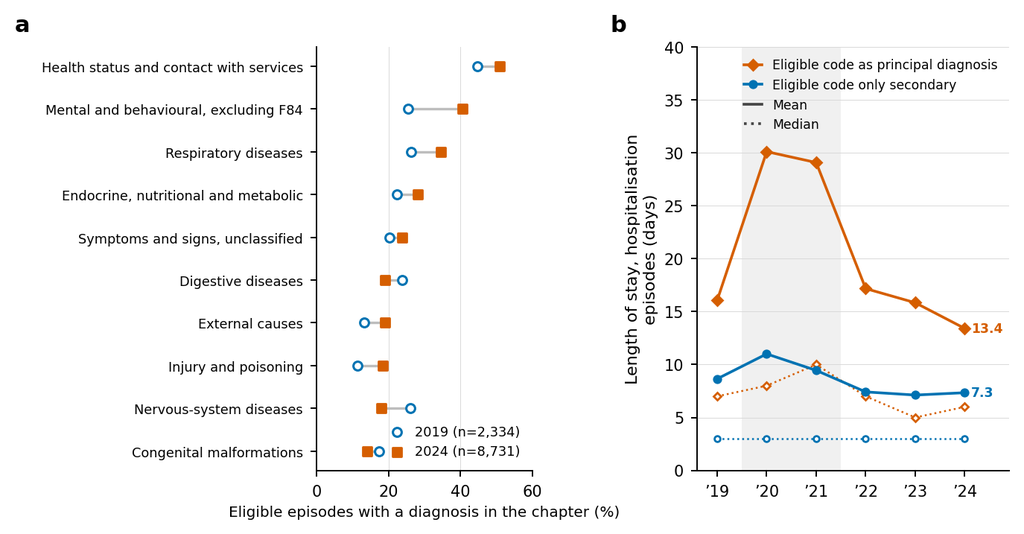

Figure S9. Drawn by the code above from the public tables in docs/study/data/.

```python
def figS9(lang):
    style(); fig = plt.figure(figsize=(175/25.4, 95/25.4))
    gs = fig.add_gridspec(1, 2, left=0.10, right=0.975, top=0.93, bottom=0.17, wspace=0.45, width_ratios=[1.35, 1])
    a = fig.add_subplot(gs[0, 0]); clean(a, grid='x'); pos = a.get_position(); a.set_position([pos.x0 + 0.20, pos.y0, pos.width - 0.20, pos.height])
    ch = pd.read_csv(DATA/'clinical_chapters_selected.csv'); order = ch[ch.year == 2024].sort_values('pct_of_f84_episodes', ascending=False).group_label.tolist()
    for i, lab in enumerate(order):
        v0 = ch[(ch.group_label == lab) & (ch.year == 2019)].pct_of_f84_episodes; v1 = ch[(ch.group_label == lab) & (ch.year == 2024)].pct_of_f84_episodes
        v0 = float(v0.iloc[0]) if len(v0) else np.nan; v1 = float(v1.iloc[0]) if len(v1) else np.nan
        a.plot([v0, v1], [i, i], color=LIGHT, lw=1.2, zorder=1); a.scatter([v0], [i], s=18, facecolors='white', edgecolors=BLUE, linewidths=1.1, zorder=3); a.scatter([v1], [i], s=18, color=ORANGE, marker='s', zorder=3)
    n19 = int(ch[ch.year == 2019].n_f84_episodes_cell.iloc[0]); n24 = int(ch[ch.year == 2024].n_f84_episodes_cell.iloc[0])
    a.scatter([], [], s=18, facecolors='white', edgecolors=BLUE, linewidths=1.1, label=f'2019 (n={num(n19, lang)})'); a.scatter([], [], s=18, color=ORANGE, marker='s', label=f'2024 (n={num(n24, lang)})')
    a.set_yticks(range(len(order))); a.set_yticklabels([CHAP_EN.get(l, l) if lang == 'en' else l for l in order], fontsize=6.4); a.invert_yaxis(); a.set_xlim(0, 60)
    a.set_xlabel(text('Eligible episodes with a diagnosis in the chapter (%)', 'Episodios elegibles con un diagnóstico del capítulo (%)', lang), fontsize=7.2); a.legend(loc='lower right', fontsize=6.4, handlelength=1.2)
    b = fig.add_subplot(gs[0, 1]); clean(b); shade_pandemic(b)
    los = pd.read_csv(TIDY/'grd_length_of_stay.csv').query("variant=='sin_rett' and panel=='observed' and activity=='hospitalisation'")
    for posn, col, mk, en, es in (('principal', ORANGE, 'D', 'Eligible code as principal diagnosis', 'Código elegible principal'), ('secondary_only', BLUE, 'o', 'Eligible code only secondary', 'Código elegible solo secundario')):
        z = los[los.position == posn].set_index('year').reindex(YRS_GRD); b.plot(z.index, z.mean_days, color=col, marker=mk, label=text(en, es, lang)); b.plot(z.index, z.median_days, color=col, marker=mk, mfc='white', ls=':', lw=0.9, ms=2.8)
        end_label(b, 2024, z.mean_days[2024], num(z.mean_days[2024], lang, 1), col, dx=3, size=6.2)
    b.plot([], [], color='#444', ls='-', label=text('Mean', 'Media', lang)); b.plot([], [], color='#444', ls=':', label=text('Median', 'Mediana', lang))
    b.set_ylim(0, 40); year_ticks(b, YRS_GRD, short=True); b.set_xlim(2018.6, 2024.9); b.set_ylabel(text('Length of stay, hospitalisation\nepisodes (days)', 'Estancia, episodios de\nhospitalización (días)', lang)); b.legend(loc='upper right', fontsize=6.2, handlelength=1.4, ncol=1)
    for ax, ch_ in zip([a, b], 'ab'): letter(fig, ax, ch_, dx=(-0.34 if ch_ == 'a' else -0.085), dy=0.02)
    save(fig, 'Figure_S9', lang, close=False)
    return fig

plt.close(figS9('es'))          # Spanish plate: exported to docs/study/figures/es/
figS9('en')                     # English plate: exported and shown here
```

## Tables

Each table is computed here from the aggregated CSVs in `docs/study/data/`, which ship with the repository, so the whole page can be rebuilt from a clone without the source microdata.

**Show the code that produced this**

```python
import pandas as pd

# Eligible hospital episodes and their rate per 100 000 GRD episodes of the same panel, by year.
# load_grd_summary() is the same loader the figures above use, so the table cannot apply a different
# case definition than the plates: variant sin_rett (F84 family without F84.2), all activities.
observed = (load_grd_summary()
            .query("panel == 'observed' and position == 'any'")
            .loc[:, ["year", "n_episodes_f84", "n_episodes_total_same_panel_activity",
                     "rate_per_100k_episodes", "rate_lo", "rate_hi"]]
            .sort_values("year"))
observed["95% CI"] = observed.apply(lambda r: f"{r.rate_lo:.1f}–{r.rate_hi:.1f}", axis=1)
show_table(observed.drop(columns=["rate_lo", "rate_hi"]).rename(columns={
    "year": "Year", "n_episodes_f84": "Eligible episodes",
    "n_episodes_total_same_panel_activity": "All GRD episodes of the panel",
    "rate_per_100k_episodes": "Per 100 000 GRD episodes"}),
    "Eligible hospital episodes by year, observed panel, code in any diagnostic position",
    {"Per 100 000 GRD episodes": 1})
```

Eligible hospital episodes by year, observed panel, code in any diagnostic position

| Year | Eligible episodes | All GRD episodes of the panel | Per 100 000 GRD episodes | 95% CI |
| --- | --- | --- | --- | --- |
| 2019 | 2,334 | 1,151,475 | 202.7 | 194.6–211.1 |
| 2020 | 1,609 | 781,912 | 205.8 | 195.8–216.1 |
| 2021 | 2,367 | 816,909 | 289.8 | 278.2–301.7 |
| 2022 | 3,859 | 932,839 | 413.7 | 400.7–426.9 |
| 2023 | 6,423 | 1,039,587 | 617.8 | 602.8–633.1 |
| 2024 | 8,731 | 1,085,813 | 804.1 | 787.3–821.1 |

**Show the code that produced this**

```python
# The tables this page reads, so the reader can see exactly what the figures were built from.
show_table(pd.DataFrame(rh.data_tables()).rename(columns={"name": "Table", "rows": "Rows", "kb": "Size (KB)"}),
           f"The {len(rh.data_tables())} public tidy tables in docs/study/data/", {"Size (KB)": 1})
```

The 79 public tidy tables in docs/study/data/

| Table | Rows | Size (KB) |
| --- | --- | --- |
| Figure5_chapter_endpoints.csv | 20 | 3.9 |
| Figure5_hospital_2024.csv | 72 | 5.9 |
| Figure5_principal_endpoints.csv | 20 | 4.1 |
| Figure_S1_dataflow_count_provenance.csv | 31 | 2.2 |
| S3_grd_gini_coverage.csv | 6 | 0.2 |
| S3_grd_gini_fixed65_sensitivity.csv | 6 | 0.2 |
| S3_grd_lisa_full2019_2024.csv | 342 | 162.2 |
| S3_grd_moran_sensitivities.csv | 36 | 9.6 |
| S3_grd_regional_endpoints.csv | 32 | 2.7 |
| S3_grd_standardised_full2019_2024.csv | 346 | 144.4 |
| S4_correlations_selected_sensitivities.csv | 32 | 3.7 |
| S4_regions_A05_P2.csv | 15 | 0.4 |
| S4_regions_GRD_A05.csv | 16 | 0.4 |
| S4_regions_GRD_P2.csv | 16 | 0.4 |
| S4_reporting_audit.csv | 8 | 0.4 |
| S7d_threshold_sensitivity.csv | 13 | 0.8 |
| Table_S7_correlations_compact.csv | 10 | 0.6 |
| Table_regional_GRD_endpoints_expanded_numeric.csv | 16 | 2.5 |
| a05_age_hombre_2021.csv | 10 | 0.8 |
| a05_age_hombre_2025.csv | 10 | 0.8 |
| a05_age_mujer_2021.csv | 10 | 0.8 |
| a05_age_mujer_2025.csv | 10 | 0.8 |
| a05_sex_counts.csv | 5 | 0.2 |
| burden_length_of_stay.csv | 6 | 0.5 |
| burden_multiplicity.csv | 5 | 0.3 |
| burden_readmission.csv | 6 | 0.4 |
| case_definition_subcodes.csv | 6 | 0.4 |
| case_definition_variant_rates.csv | 6 | 0.2 |
| central_endpoints_table.csv | 20 | 1.7 |
| central_reporting_audit.csv | 12 | 0.7 |
| clinical_chapters_selected.csv | 20 | 3.9 |
| clinical_principal_selected.csv | 20 | 4.1 |
| communes_public.csv | 346 | 18.2 |
| coverage_layers_year.csv | 7 | 4.7 |
| education_summary_year.csv | 7 | 4.3 |
| expanded_a27_assisted_referrals.csv | 3 | 1.6 |
| expanded_age_distribution.csv | 12 | 1.7 |
| expanded_deis_principal_comparison.csv | 6 | 6.5 |
| expanded_hospital_quantiles.csv | 5 | 0.7 |
| expanded_selected_models.csv | 13 | 15.4 |
| f80_f89_denominators.csv | 12 | 0.3 |
| f80_f89_episode_rates.csv | 84 | 14.0 |
| f80_f89_raw_counts.csv | 951 | 29.5 |
| f80_f89_standardised_by_sex.csv | 84 | 14.9 |
| fig3a_pie.csv | 7 | 1.0 |
| fig3b_index.csv | 16 | 1.2 |
| fig3c_surveys.csv | 4 | 5.2 |
| fig3d_sex_ratios.csv | 11 | 2.0 |
| figS5_all_era_source.csv | 56 | 20.9 |
| grd_age_hombre_2019.csv | 10 | 0.8 |
| grd_age_hombre_2024.csv | 10 | 0.8 |
| grd_age_mujer_2019.csv | 10 | 0.8 |
| grd_age_mujer_2024.csv | 10 | 0.8 |
| grd_age_sex_year.csv | 324 | 16.1 |
| grd_coding_depth_year.csv | 51 | 5.7 |
| grd_identifier_audit.csv | 6 | 0.9 |
| grd_length_of_stay.csv | 366 | 70.3 |
| grd_raw_rett_recount.csv | 6 | 0.4 |
| grd_readmission.csv | 324 | 65.7 |
| grd_selected_definition.csv | 192 | 28.2 |
| grd_sex_counts.csv | 6 | 0.2 |
| grd_year_summary.csv | 576 | 85.0 |
| junaeb_denominator_audit.csv | 12 | 5.9 |
| models_a05_standardised_rates.csv | 15 | 6.4 |
| models_convergence_index.csv | 158 | 54.4 |
| models_population_rates.csv | 108 | 43.2 |
| models_summary.csv | 331 | 401.2 |
| models_summary_preserved.csv | 331 | 400.3 |
| p2_under10_sensitivity.csv | 7 | 0.5 |
| pie_enriched_context_verified.csv | 7 | 0.6 |
| pie_source_provenance.csv | 97 | 46.9 |
| rem_a05_age_sex_annual.csv | 180 | 19.9 |
| rem_code_dictionary_check.csv | 399 | 139.8 |
| rem_pathway_annual.csv | 346 | 138.8 |
| rem_selected_series.csv | 61 | 24.0 |
| selected_models_scientific.csv | 8 | 9.6 |
| survey_domains_enriched_verified.csv | 35 | 48.1 |
| survey_estimates.csv | 35 | 43.7 |
| survey_estimates_verified.csv | 35 | 43.7 |

Commune-level tables that carry cells under five cases are withheld: the site publishes the masked commune extract instead, without commune identifiers.